# Bivariate Data

Monika Peteva Petkova

mpetevap@uni-sofia.bg

2018

The relationship bertween 2 variables:

# Bivariate categorical data

#### Example 1:

Students who smoke study less amount: * 1 - less than 5 hours studing, * 2 - 5 - 10 hours studying, * 3 - more than 10 hours studying)

```r
smokes = c("Yes","No","No","Yes","No","Yes","Yes","Yes","No","Yes")
amount = c(1,2,2,3,3,1,2,1,3,2)
table(smokes,amount)
```

```
      amount
smokes 1 2 3
   No  0 2 2
   Yes 3 2 1
```

```r
prop.table(table(smokes,amount))
```

```
      amount
smokes   1   2   3
   No  0.0 0.2 0.2
   Yes 0.3 0.2 0.1
```

```r
prop.table(table(smokes,amount),1)
```

```
      amount
smokes                  1                  2                  3
   No  0.0000000000000000 0.5000000000000000 0.5000000000000000
   Yes 0.5000000000000000 0.3333333333333333 0.1666666666666667
```

```r
prop.table(table(smokes,amount),2)
```

```
      amount
smokes                  1                  2                  3
   No  0.0000000000000000 0.5000000000000000 0.6666666666666666
   Yes 1.0000000000000000 0.5000000000000000 0.3333333333333333
```

```r
options(digits = 3)
```

#### Example 2:

```r
hair = c("blond", "blond", "black", "blond", "brown", "brown",
         "brown", "brown", "black", "brown", "black", "brown",
         "black", "black", "black", "brown", "brown", "brown",
         "brown", "brown", "black", "brown", "black", "brown",
         "blond", "blond", "black", "blond", "brown", "brown",
         "brown", "brown", "black", "brown", "black", "brown",
         "brown", "brown", "black", "brown", "black", "brown",
         "blond", "blond", "black", "blond", "brown", "brown")
eyes = c("blue", "green", "brown",  "blue", "green", "brown",
         "brown", "black", "black", "green", "brown", "brown",
         "green", "black", "black", "brown", "brown", "black",
         "green", "black", "black", "brown", "brown", "black",
         "brown",  "blue", "green", "brown", "brown", "black",
         "black", "green", "brown",  "blue", "green", "brown",
         "brown", "black", "brown",  "blue", "green", "brown",
         "blue", "green", "brown",  "blue", "green", "brown")
table(hair, eyes)
```

```
       eyes
hair    black blue brown green
  black     4    0     6     4
  blond     0    5     2     2
  brown     7    2    11     5
```

```r
prop.table(table(hair, eyes))
```

```
       eyes
hair     black   blue  brown  green
  black 0.0833 0.0000 0.1250 0.0833
  blond 0.0000 0.1042 0.0417 0.0417
  brown 0.1458 0.0417 0.2292 0.1042
```

```r
prop.table(table(hair, eyes),1)
```

```
       eyes
hair    black  blue brown green
  black 0.286 0.000 0.429 0.286
  blond 0.000 0.556 0.222 0.222
  brown 0.280 0.080 0.440 0.200
```

```r
prop.table(table(hair, eyes),2)
```

```
       eyes
hair    black  blue brown green
  black 0.364 0.000 0.316 0.364
  blond 0.000 0.714 0.105 0.182
  brown 0.636 0.286 0.579 0.455
```

Барплот

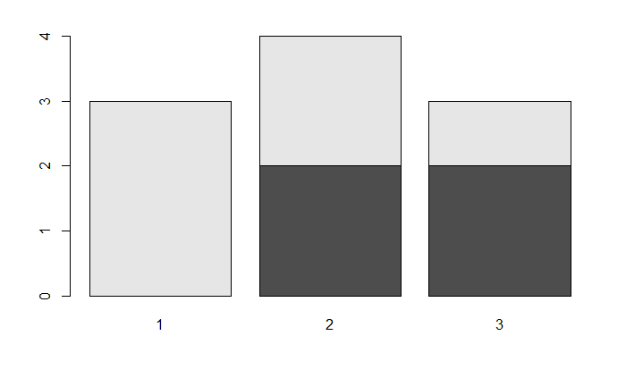

```r
barplot(table(smokes,amount))
```

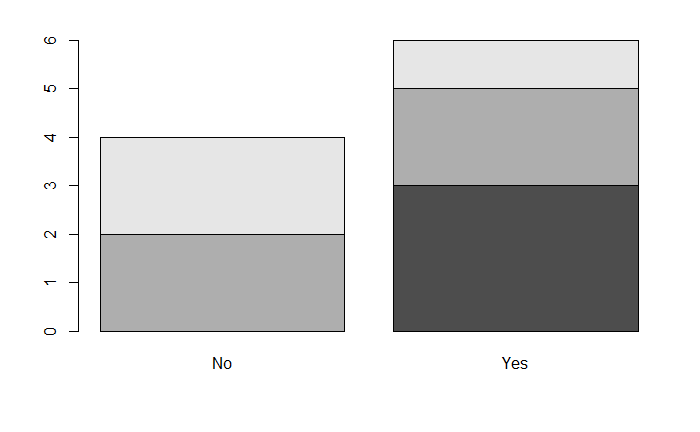

```r
barplot(table(amount,smokes))
```

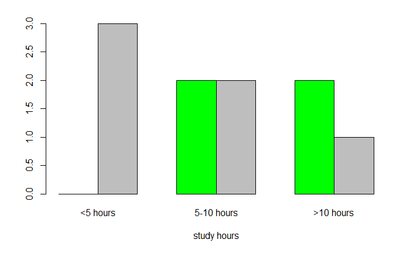

```r
barplot(table(smokes,amount),
        names.arg = c("<5 hours", "5-10 hours", ">10 hours"),
        beside = TRUE,
        col = c("Green", "Grey"),
        xlab = "study hours")
```

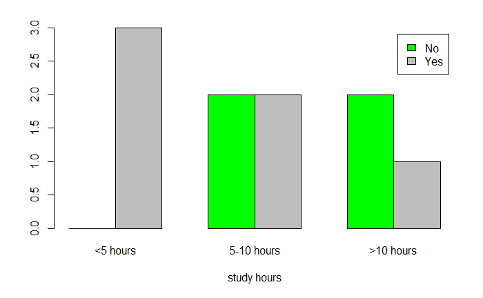

```r
barplot(table(smokes,amount),
        names.arg = c("<5 hours", "5-10 hours", ">10 hours"),
        legend.text = TRUE,
        beside = TRUE,
        col = c("Green", "Grey"),
        xlab = "study hours")
```

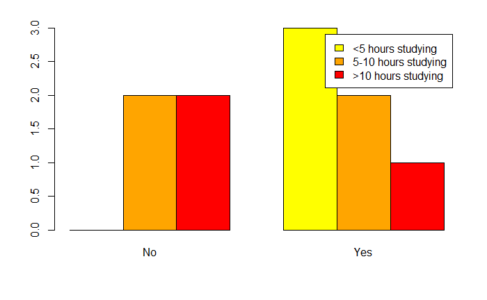

```r
barplot(table(amount,smokes),
        legend.text = c("<5 hours studying","5-10 hours studying",">10 hours studying"),
        beside = TRUE,
        col = c("Yellow", "Orange", "Red"))
```

You can also see:

- apply, tapply, mapply, sapply

You can also see:

- lattice, ggplot2

# Categorical vs Numerical data

#### Example 1:

Drug test - experimental group and control group

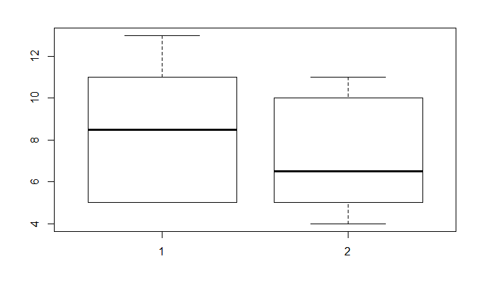

```r
experimentalGroup = c(5, 5, 5, 13, 7, 11, 11, 9, 8, 9)
controlGroup = c(11, 8, 4, 5, 9, 5, 10, 5, 4, 10)
boxplot(experimentalGroup, controlGroup)
```

#### The same example:

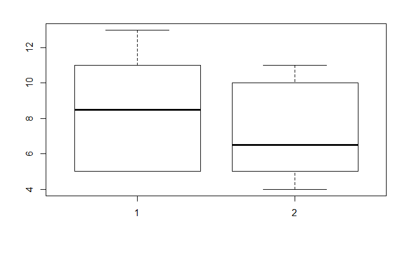

```r
amount = c(5, 5, 5, 13, 7, 11, 11, 9, 8, 9, 11, 8, 4, 5, 9, 5, 10, 5, 4, 10)
category = c(1, 1, 1, 1, 1, 1, 1, 1, 1, 1, 2, 2, 2, 2, 2, 2, 2, 2, 2, 2)
boxplot(amount ~ category)
```

breaking up the values in amount, by the categories in category  
amount by category

# Numerical vs numerical data

### Compare the distributions

#### Example

Home data * boxplot

```r
library("UsingR")
head(home)
```

|  | old | new |
| --- | --- | --- |
| 1 | 64200 | 257500 |
| 2 | 72100 | 276800 |
| 3 | 87600 | 364600 |
| 4 | 59000 | 160400 |
| 5 | 83200 | 333500 |
| 6 | 49100 | 145600 |

```r
names(home)
```

```
[1] "old" "new"
```

```r
home$old
```

```
 [1]  64200  72100  87600  59000  83200  49100  79600  69300  93100 105400  74500 105900  82600  77800  77200
```

```r
home$new
```

```
 [1] 257500 276800 364600 160400 333500 145600 350200 205200 599300 514400 309700 437000 306400 354400 324800
```

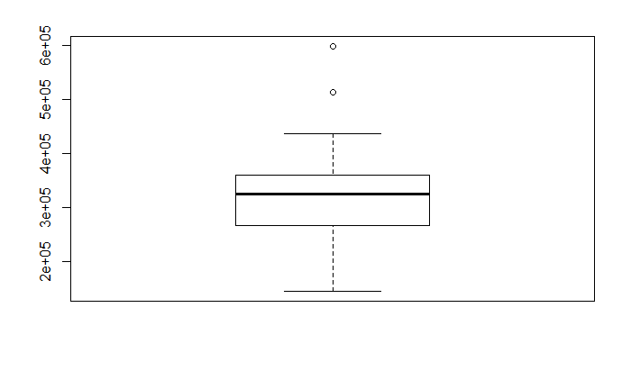

```r
boxplot(home$new)
```

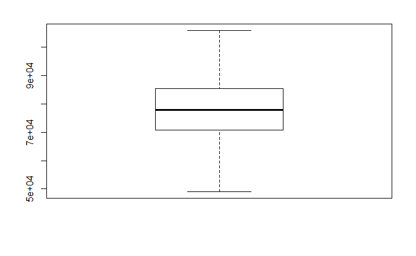

```r
boxplot(home$old)
```

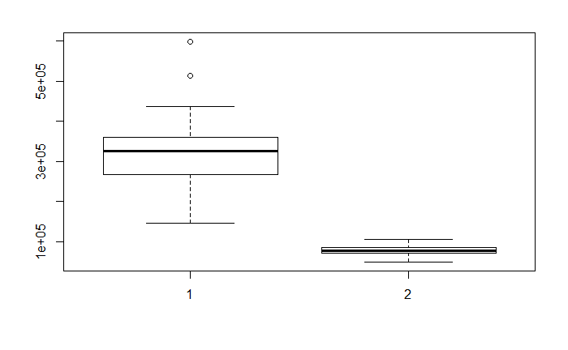

```r
boxplot(home$new, home$old)
```

```r
mean(home$new)
```

```
[1] 329320
```

```r
mean(home$old)
```

```
[1] 78707
```

```r
sd(home$new)
```

```
[1] 121774
```

```r
sd(home$old)
```

```
[1] 15590
```

```r
scale(home$old)
```

```
         [,1]
 [1,] -0.9305
 [2,] -0.4238
 [3,]  0.5704
 [4,] -1.2641
 [5,]  0.2882
 [6,] -1.8991
 [7,]  0.0573
 [8,] -0.6034
 [9,]  0.9232
[10,]  1.7122
[11,] -0.2698
[12,]  1.7443
[13,]  0.2497
[14,] -0.0582
[15,] -0.0966
attr(,"scaled:center")
[1] 78707
attr(,"scaled:scale")
[1] 15590
```

```r
scale(home$new)
```

```
         [,1]
 [1,] -0.5898
 [2,] -0.4313
 [3,]  0.2897
 [4,] -1.3872
 [5,]  0.0343
 [6,] -1.5087
 [7,]  0.1715
 [8,] -1.0193
 [9,]  2.2171
[10,]  1.5199
[11,] -0.1611
[12,]  0.8843
[13,] -0.1882
[14,]  0.2060
[15,] -0.0371
attr(,"scaled:center")
[1] 329320
attr(,"scaled:scale")
[1] 121774
```

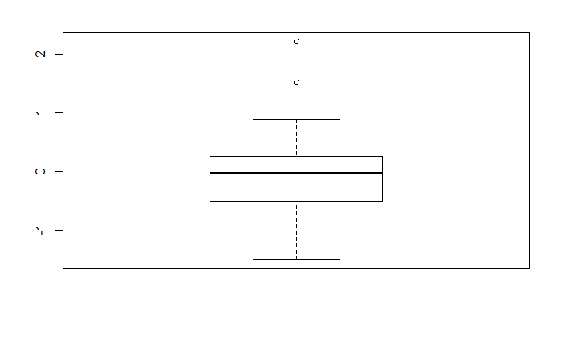

```r
boxplot(scale(home$new))
```

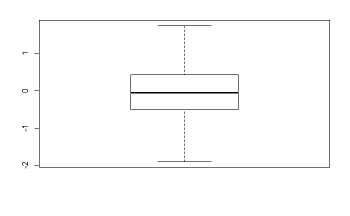

```r
boxplot(scale(home$old))
par(mfrow = c(1, 2))
```

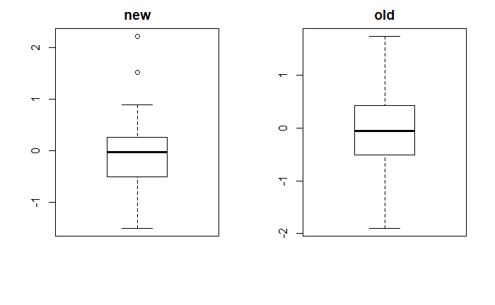

```r
boxplot(scale(home$new), main = "new")
boxplot(scale(home$old), main = "old")
```

- Dot plots (Точкова диаграма)

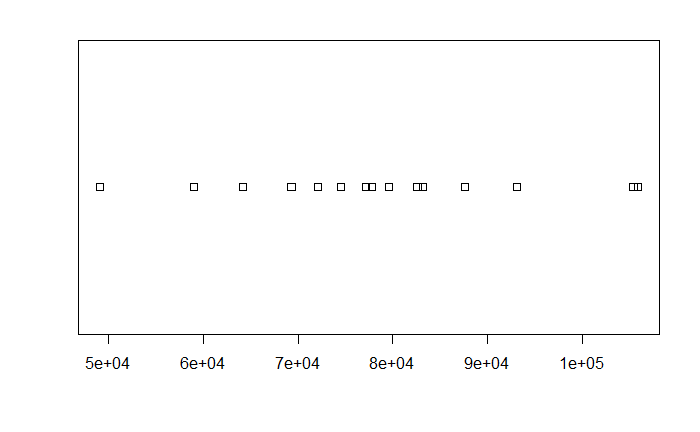

```r
stripchart(home$old)
```

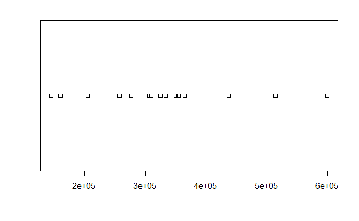

```r
stripchart(home$new)
par(mfrow = c(2, 1))
```

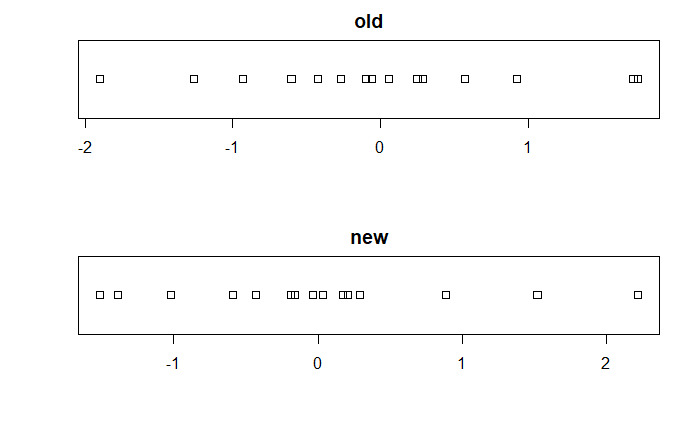

```r
stripchart(scale(home$old), main = "old")
stripchart(scale(home$new), main = "new")
```

- Violin Plot instead of boxplots

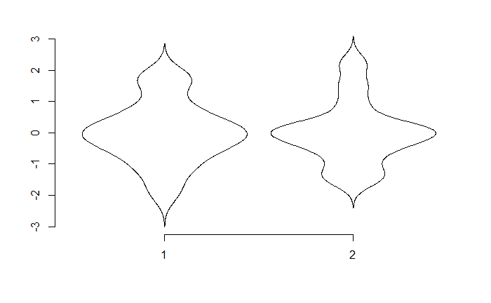

```r
violinplot(scale(home$old), scale(home$new))
```

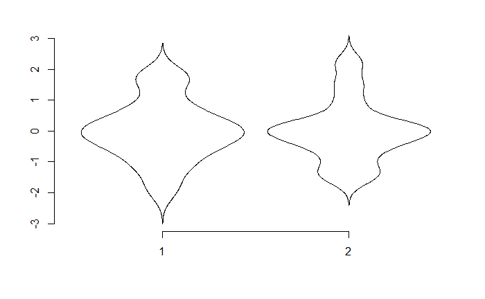

```r
simple.violinplot(scale(home$old), scale(home$new))
```

### Compare relationships

Investigate one numerical variable against another

- Scatter plot

```r
home
```

|  | old | new |
| --- | --- | --- |
| 1 | 64200 | 257500 |
| 2 | 72100 | 276800 |
| 3 | 87600 | 364600 |
| 4 | 59000 | 160400 |
| 5 | 83200 | 333500 |
| 6 | 49100 | 145600 |
| 7 | 79600 | 350200 |
| 8 | 69300 | 205200 |
| 9 | 93100 | 599300 |
| 10 | 105400 | 514400 |

[output cut: 5 more lines]

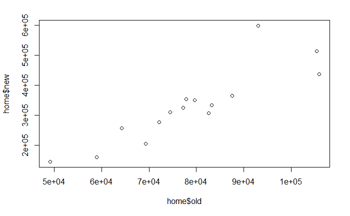

```r
plot(home$old, home$new)
```

```r
min(home$old)
```

```
[1] 49100
```

```r
min(home$new)
```

```
[1] 145600
```

Entire data set

```r
homedata
```

|  | y1970 | y2000 |
| --- | --- | --- |
| 1 | 89700 | 359100 |
| 2 | 118400 | 504500 |
| 3 | 116400 | 477300 |
| 4 | 122000 | 500400 |
| 5 | 91500 | 433900 |
| 6 | 102800 | 464800 |
| 7 | 71700 | 395300 |
| 8 | 71400 | 340700 |
| 9 | 68200 | 297400 |
| 10 | 71900 | 198600 |

[output cut: 990 more lines]

```r
plot(homedata$y1970, homedata$y2000)
```

[output not shown]

Strong linear trend

- **Pearson correlation coefficients** [-1 < Corr < 1]
- Scaled Covariance between X and Y
- How one variable varies as the other does
- - 1 - strong linear relationship
- - 0 - weak one (no **linear** realtionship)

The Pearson correlation coefficient indicates the strength of a linear relationship between two variables, but its value generally does not completely characterize their relationship.  
See [picture1](https://en.wikipedia.org/wiki/Correlation_and_dependence#/media/File:Correlation_examples2.svg) and [picture2](https://en.wikipedia.org/wiki/Correlation_and_dependence#/media/File:Anscombe%27s_quartet_3.svg) from [here:](https://en.wikipedia.org/wiki/Correlation_and_dependence)

```r
cor(home$old, home$new)
```

```
[1] 0.881
```

```r
cor(home$old, home$new)^2
```

```
[1] 0.776
```

Funny online games to predict correlations: [game1](http://guessthecorrelation.com/) [game2](http://istics.net/Correlations/)

```r
homedata
```

|  | y1970 | y2000 |
| --- | --- | --- |
| 1 | 89700 | 359100 |
| 2 | 118400 | 504500 |
| 3 | 116400 | 477300 |
| 4 | 122000 | 500400 |
| 5 | 91500 | 433900 |
| 6 | 102800 | 464800 |
| 7 | 71700 | 395300 |
| 8 | 71400 | 340700 |
| 9 | 68200 | 297400 |
| 10 | 71900 | 198600 |

[output cut: 990 more lines]

```r
plot(homedata$y1970, homedata$y2000)
```

[output not shown]

```r
plot(homedata$y2000 ~ homedata$y1970)
```

[output not shown]

```r
cor(homedata$y1970, homedata$y2000)
```

```
[1] 0.896
```

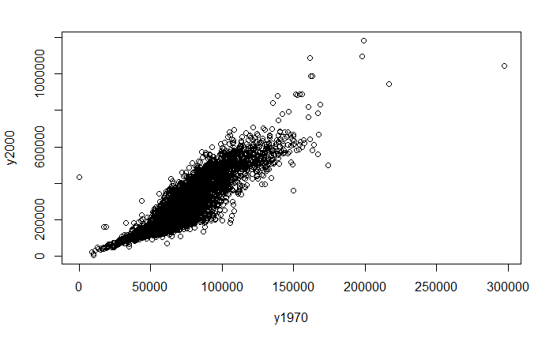

```r
plot(homedata)
```

# Linear regression

```r
homedata
```

|  | y1970 | y2000 |
| --- | --- | --- |
| 1 | 89700 | 359100 |
| 2 | 118400 | 504500 |
| 3 | 116400 | 477300 |
| 4 | 122000 | 500400 |
| 5 | 91500 | 433900 |
| 6 | 102800 | 464800 |
| 7 | 71700 | 395300 |
| 8 | 71400 | 340700 |
| 9 | 68200 | 297400 |
| 10 | 71900 | 198600 |

[output cut: 990 more lines]

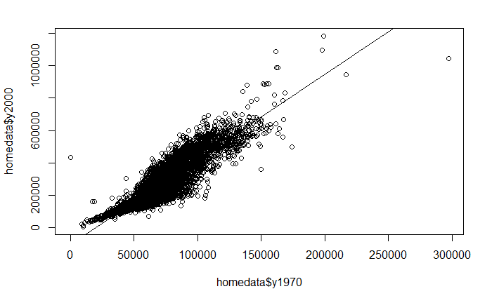

```r
plot(homedata$y1970, homedata$y2000)
abline(lm(homedata$y2000 ~ homedata$y1970))
```

```
Call:
lm(formula = y ~ x)

Coefficients:
(Intercept)            x
  -1.04e+05     5.26e+00
```

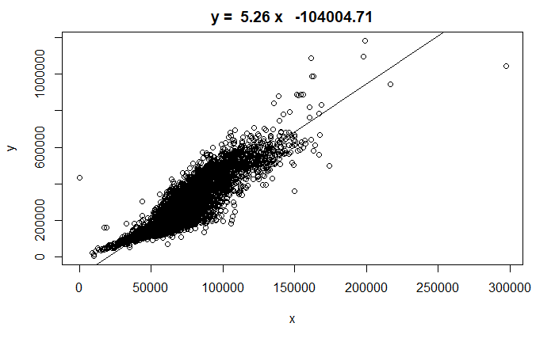

```r
simple.lm(homedata$y1970, homedata$y2000)
```

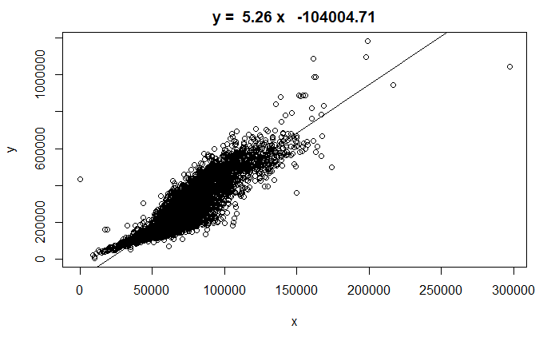

```r
lm.res = simple.lm(homedata$y1970, homedata$y2000)
```

```r
coef(lm.res)
```

```
(Intercept)           x
  -1.04e+05    5.26e+00
```

```r
coef(lm.res)[1]
```

```
(Intercept)
    -104005
```

```r
coef(lm.res)[2]
```

```
   x
5.26
```

```
Call:
lm(formula = y ~ x)

Coefficients:
(Intercept)            x
  -1.04e+05     5.26e+00
```

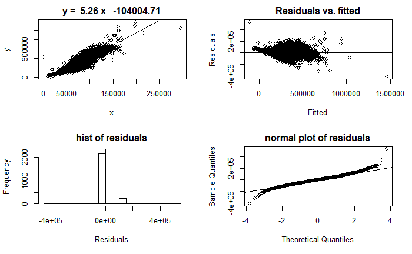

```r
simple.lm(homedata$y1970, homedata$y2000, show.residuals = TRUE)
```

```r
summary(lm(homedata$y2000 ~ homedata$y1970))
```

```
Call:
lm(formula = homedata$y2000 ~ homedata$y1970)

Residuals:
    Min      1Q  Median      3Q     Max
-416665  -36308     809   34372  536605

Coefficients:
                Estimate Std. Error t value Pr(>|t|)
(Intercept)    -1.04e+05   2.34e+03   -44.5   <2e-16 ***
homedata$y1970  5.26e+00   3.15e-02   167.1   <2e-16 ***
---
Signif. codes:  0 ‘***’ 0.001 ‘**’ 0.01 ‘*’ 0.05 ‘.’ 0.1 ‘ ’ 1

Residual standard error: 58000 on 6839 degrees of freedom
Multiple R-squared:  0.803, Adjusted R-squared:  0.803
F-statistic: 2.79e+04 on 1 and 6839 DF,  p-value: <2e-16
```

```r
head(emissions)
```

|  | GDP | perCapita | CO2 |
| --- | --- | --- | --- |
| UnitedStates | 8083000 | 29647 | 6750 |
| Japan | 3080000 | 24409 | 1320 |
| Germany | 1740000 | 21197 | 1740 |
| France | 1320000 | 22381 | 550 |
| UnitedKingdom | 1242000 | 21010 | 675 |
| Italy | 1240000 | 21856 | 540 |

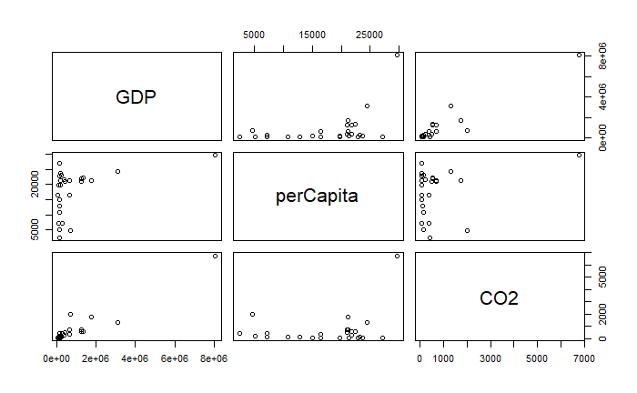

```r
plot(emissions)
```

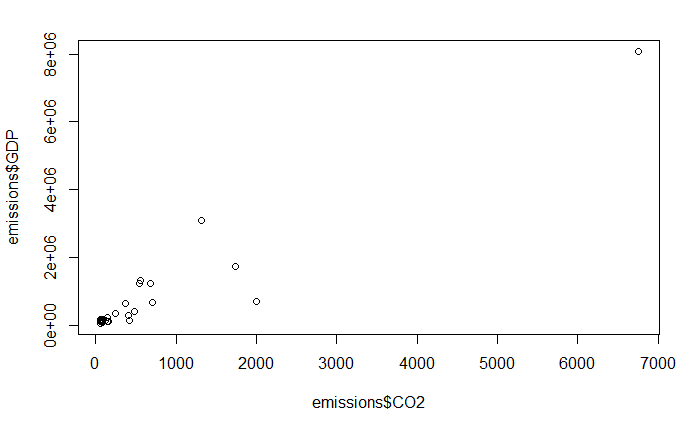

```r
plot(emissions$CO2, emissions$GDP)
```

```r
florida
```

|  | County | GORE | BUSH | BUCHANAN | NADER | BROWN | HAGELIN | HARRIS | MCREYNOLDS | MOOREHEAD | PHILLIPS | Total |
| --- | --- | --- | --- | --- | --- | --- | --- | --- | --- | --- | --- | --- |
| 1 | ALACHUA | 47300 | 34062 | 262 | 3215 | 658 | 42 | 4 | 658 | 21 | 20 | 86242 |
| 2 | BAKER | 2392 | 5610 | 73 | 53 | 17 | 3 | 0 | 0 | 3 | 3 | 8154 |
| 3 | BAY | 18850 | 38637 | 248 | 828 | 171 | 18 | 5 | 3 | 37 | 18 | 58815 |
| 4 | BRADFORD | 3072 | 5413 | 65 | 84 | 28 | 2 | 0 | 0 | 3 | 2 | 8669 |
| 5 | BREVARD | 97318 | 115185 | 570 | 4470 | 643 | 39 | 11 | 11 | 76 | 72 | 218395 |
| 6 | BROWARD | 386518 | 177279 | 789 | 7099 | 1212 | 128 | 49 | 35 | 123 | 74 | 573306 |
| 7 | CALHOUN | 2155 | 2873 | 90 | 39 | 10 | 1 | 0 | 1 | 3 | 2 | 5174 |
| 8 | CHARLOTTE | 29641 | 35419 | 182 | 1461 | 127 | 15 | 6 | 3 | 12 | 19 | 66885 |
| 9 | CITRUS | 25501 | 29744 | 270 | 1378 | 194 | 16 | 5 | 0 | 28 | 18 | 57154 |
| 10 | CLAY | 14630 | 41745 | 186 | 562 | 204 | 14 | 1 | 3 | 9 | 6 | 57360 |

[output cut: 57 more lines]